# Logistic regression workshop

Neil Stewart

```r
library(tidyverse)
library(emmeans) # for emmeans() and pairs()
options(width=100)
```

# Logistic regression workshop

In this workshop we will run a logistic regression to predict the subscriptions during a marketing campaign

## Tasks for today

1. Get the [Bank Marketing Data Set](https://archive.ics.uci.edu/ml/datasets/Bank+Marketing) from the UCI Machine Learning Repository. We are only going to focus on subscriptions `y` and `month` in the campaign
2. Make a tibble from the “bank-additional-full.csv” (Hint: Use `read_delim()` with the `delim=";"` and `guess_max=10000` options. Why?)
3. Explore how the proportion of people subscribing to a term deposit (`y`) varies by calendar month (`month`) during the marketing campaign using a logistic regression
4. Use the logistic regression model to make predictions for probability of a subscription in each month
5. What is the odds of a subscription in September?
6. You should have run a logistic regression in Question 3. Use the coefficients from a `summary()` of the regression to calculate, by hand, the predictions of the model for September
7. Why does subscription vary over months? (Hint: Check the number of people contacted in each month) Draw a beautiful plot to make your conclusion irresistible

Check:

- Did you make a data dictionary?
- Are your plots beautiful, and clearly labelled?
- Have you written plain-English sentences that describe the pattern of the results, and supplemented them with statistics as necessary?

## Learning objectives for today

1. Understand the generalised linear model for logistic regression
2. Learn how to run logistic regression models in R
3. Learn how to draw wonderful plots of logistic regression data
4. Learn how to report results from a logistic regression

# Questions 1 and 2

```r
marketing <- read_delim("bank-additional-full.csv", delim=";", guess_max=1e4)
marketing <- marketing %>% mutate(subscribed=ifelse(y=="yes",1,0))

marketing <- marketing %>% mutate(month=factor(month, levels=c("mar", "apr", "may", "jun", "jul", "aug", "sep", "oct", "nov", "dec"), labels=c("March", "April", "May", "June", "July", "Aug", "Sept", "Oct", "Nov", "Dec")))
```

| Variable | Description |
| --- | --- |
| month | Month of contact |
| y | Term deposit subscription? (y/n) |

# Question 3

The proportion of people subscribing each month varies from about 10% to about 50%. I have also calculated the total number of subscriptions and the total number of contacts made to achieve those subscriptions

```r
(  marketing.by.month <- marketing %>%
    group_by(month) %>%
    summarise(prop.subscribed=mean(subscribed), total.subscribed=sum(subscribed), total.contacts=n())
)
```

```
## # A tibble: 10 x 4
##    month prop.subscribed total.subscribed total.contacts
##    <fct>           <dbl>            <dbl>          <int>
##  1 March          0.505              276.            546
##  2 April          0.205              539.           2632
##  3 May            0.0643             886.          13769
##  4 June           0.105              559.           5318
##  5 July           0.0905             649.           7174
##  6 Aug            0.106              655.           6178
##  7 Sept           0.449              256.            570
##  8 Oct            0.439              315.            718
##  9 Nov            0.101              416.           4101
## 10 Dec            0.489               89.            182
```

# Question 4

```r
m.subscribed.by.month <- glm(subscribed~month, family=binomial, data=marketing)
summary(m.subscribed.by.month)
```

```
##
## Call:
## glm(formula = subscribed ~ month, family = binomial, data = marketing)
##
## Deviance Residuals:
##     Min       1Q   Median       3Q      Max
## -1.1868  -0.4713  -0.4355  -0.3647   2.3424
##
## Coefficients:
##             Estimate Std. Error z value Pr(>|z|)
## (Intercept)  0.02198    0.08560   0.257   0.7974
## monthApril  -1.37862    0.09829 -14.027   <2e-16 ***
## monthMay    -2.69893    0.09238 -29.217   <2e-16 ***
## monthJune   -2.16362    0.09657 -22.405   <2e-16 ***
## monthJuly   -2.32994    0.09498 -24.531   <2e-16 ***
## monthAug    -2.15402    0.09505 -22.662   <2e-16 ***
## monthSept   -0.22619    0.12007  -1.884   0.0596 .
## monthOct    -0.26834    0.11394  -2.355   0.0185 *
## monthNov    -2.20332    0.10001 -22.031   <2e-16 ***
## monthDec    -0.06594    0.17122  -0.385   0.7001
## ---
## Signif. codes:  0 '***' 0.001 '**' 0.01 '*' 0.05 '.' 0.1 ' ' 1
##
## (Dispersion parameter for binomial family taken to be 1)
##
##     Null deviance: 28999  on 41187  degrees of freedom
## Residual deviance: 26823  on 41178  degrees of freedom
## AIC: 26843
##
## Number of Fisher Scoring iterations: 5
```

```r
anova(m.subscribed.by.month, test="Chisq")
```

```
## Analysis of Deviance Table
##
## Model: binomial, link: logit
##
## Response: subscribed
##
## Terms added sequentially (first to last)
##
##
##       Df Deviance Resid. Df Resid. Dev  Pr(>Chi)
## NULL                  41187      28999
## month  9   2175.3     41178      26824 < 2.2e-16 ***
## ---
## Signif. codes:  0 '***' 0.001 '**' 0.01 '*' 0.05 '.' 0.1 ' ' 1
```

Calendar month has a significant effect on the proportion of people subscribing, $\chi^2(9, 41178)=2175.3$, $p < .0001$

```r
summary(  m.subscribed.by.month.emm <- emmeans(m.subscribed.by.month, ~month, type="response")  )
```

```
##  month       prob          SE  df  asymp.LCL  asymp.UCL
##  March 0.50549451 0.021396733 Inf 0.46361725 0.54729480
##  April 0.20478723 0.007865932 Inf 0.18980033 0.22063526
##  May   0.06434745 0.002091075 Inf 0.06036855 0.06856946
##  June  0.10511470 0.004205729 Inf 0.09715226 0.11364760
##  July  0.09046557 0.003386652 Inf 0.08404351 0.09732622
##  Aug   0.10602137 0.003916844 Inf 0.09858583 0.11394681
##  Sept  0.44912281 0.020833993 Inf 0.40871987 0.49020846
##  Oct   0.43871866 0.018519154 Inf 0.40281113 0.47527962
##  Nov   0.10143867 0.004714447 Inf 0.09256467 0.11105929
##  Dec   0.48901099 0.037053514 Inf 0.41712235 0.56135707
##
## Confidence level used: 0.95
## Intervals are back-transformed from the logit scale
```

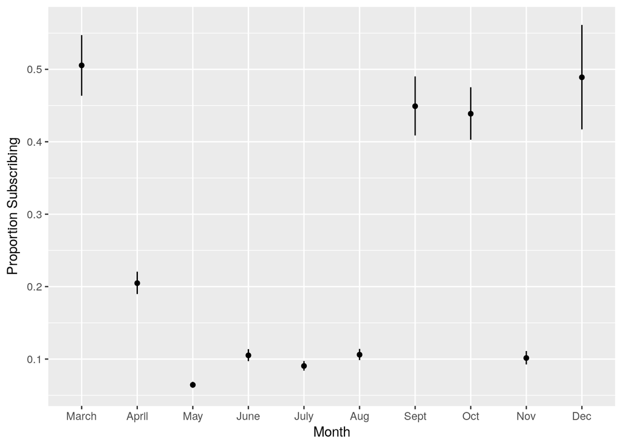

```r
ggplot(summary(m.subscribed.by.month.emm), aes(x=month, y=prob, ymin=asymp.LCL, ymax=asymp.UCL)) + geom_point() + geom_linerange() + labs(x="Month", y="Proportion Subscribing")
```

About 50% of people subscribe in March, September, October and December. About 10% of people subscribe in May, June, July, August, and November. About 20% of people subscribe in April

# Question 5

I use `emmeans()` to get predictions on the log odds scale

```r
emmeans(m.subscribed.by.month, ~month)
```

```
##  month      emmean         SE  df  asymp.LCL   asymp.UCL
##  March  0.02197891 0.08559727 Inf -0.1457887  0.18974647
##  April -1.35663815 0.04830187 Inf -1.4513081 -1.26196823
##  May   -2.67694694 0.03473152 Inf -2.7450195 -2.60887442
##  June  -2.14164337 0.04471059 Inf -2.2292745 -2.05401222
##  July  -2.30796352 0.04115931 Inf -2.3886343 -2.22729276
##  Aug   -2.13204123 0.04132528 Inf -2.2130373 -2.05104518
##  Sept  -0.20421554 0.08420786 Inf -0.3692599 -0.03917117
##  Oct   -0.24636392 0.07520633 Inf -0.3937656 -0.09896222
##  Nov   -2.18134054 0.05172250 Inf -2.2827148 -2.07996632
##  Dec   -0.04396312 0.14828568 Inf -0.3345977  0.24667147
##
## Results are given on the logit (not the response) scale.
## Confidence level used: 0.95
```

```r
exp(-0.20421554) # Bad! Copied and pasted output. Lazy!
```

```
## [1] 0.8152866
```

The odds are the exponential of the log odds. So the odds are 1:0.82 time more likely than not to subscribe in September—that is $1/0.82=1.23$ times less likely than not to subscribe in September

# Question 6

```r
summary(m.subscribed.by.month)
```

```
##
## Call:
## glm(formula = subscribed ~ month, family = binomial, data = marketing)
##
## Deviance Residuals:
##     Min       1Q   Median       3Q      Max
## -1.1868  -0.4713  -0.4355  -0.3647   2.3424
##
## Coefficients:
##             Estimate Std. Error z value Pr(>|z|)
## (Intercept)  0.02198    0.08560   0.257   0.7974
## monthApril  -1.37862    0.09829 -14.027   <2e-16 ***
## monthMay    -2.69893    0.09238 -29.217   <2e-16 ***
## monthJune   -2.16362    0.09657 -22.405   <2e-16 ***
## monthJuly   -2.32994    0.09498 -24.531   <2e-16 ***
## monthAug    -2.15402    0.09505 -22.662   <2e-16 ***
## monthSept   -0.22619    0.12007  -1.884   0.0596 .
## monthOct    -0.26834    0.11394  -2.355   0.0185 *
## monthNov    -2.20332    0.10001 -22.031   <2e-16 ***
## monthDec    -0.06594    0.17122  -0.385   0.7001
## ---
## Signif. codes:  0 '***' 0.001 '**' 0.01 '*' 0.05 '.' 0.1 ' ' 1
##
## (Dispersion parameter for binomial family taken to be 1)
##
##     Null deviance: 28999  on 41187  degrees of freedom
## Residual deviance: 26823  on 41178  degrees of freedom
## AIC: 26843
##
## Number of Fisher Scoring iterations: 5
```

```r
(  Sept.log.odds <- unname(coef(m.subscribed.by.month)["(Intercept)"] + coef(m.subscribed.by.month)["monthSept"])  )
```

```
## [1] -0.2042155
```

```r
(  Sept.odds <- exp(Sept.log.odds)  )
```

```
## [1] 0.8152866
```

```r
p.from.odds <- function(odds) {odds/(1+odds)}
(  Sept.prob <- p.from.odds(Sept.odds)  )
```

```
## [1] 0.4491228
```

When the dummy $September=1$, to indicate it is September, all the other month dummies are $0$. This means the log odds of subscribing in September are

$\log(\frac{p}{1-p})= \beta_0 + \beta_{September} \times 1$

and then we rearrange this to get the expression for the probability instead of the log odds

# Question 7

When I calculated the proportion in each month for Question 3, I also calculated the total number of subscriptions and the total number of people contacted in the campaign

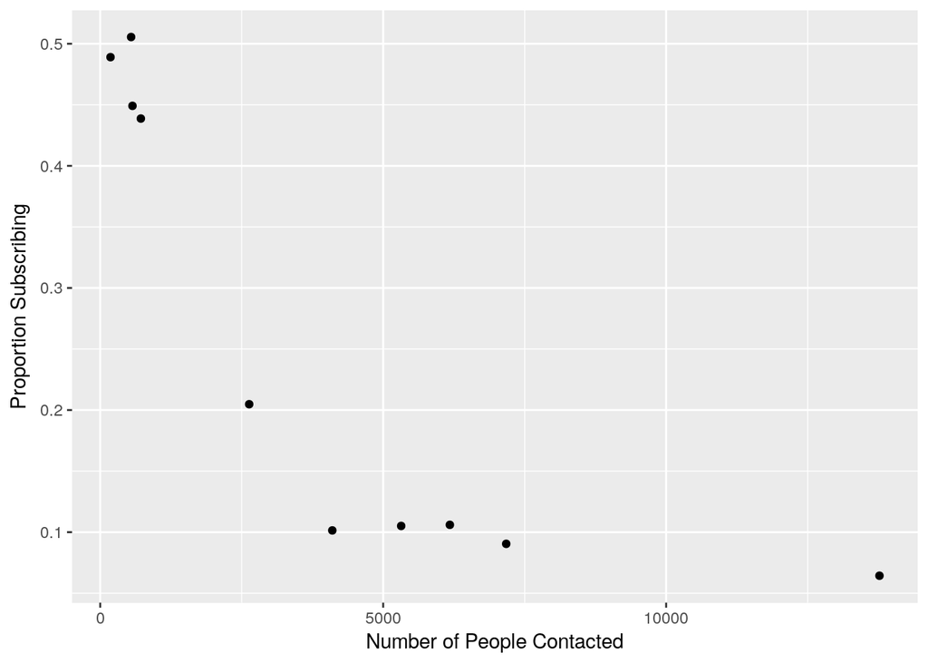

```r
ggplot(marketing.by.month, aes(x=total.contacts, y=prop.subscribed)) + geom_point() + labs(x="Number of People Contacted", y="Proportion Subscribing")
```

The variation between months is largely due to the number of people contacted. The success rate is much lower in months when many people are contacted. It seems that the extra people contacted are not likely to subscribe